# BST260 Project - Modeling and Prediction

Sun M. Kim

12/3/2020

```r
library(tidyverse)
library(caret)
```

# Statistical modeling and prediction

## 1. Effect of sea water temperature on fish in the Great Barrier Reef

### 1.1 Data exploratory analysis and visualization

In this analysis, we will examine the effects of water temperature on the number of unique fish species observed in the Great Barrier Reef from 1997 to 2011.

Originally, we wanted to examine a relationship between water temperature and coral cover. However, we quickly saw that, when visualized, there does not seem to be a linear relation and we did not want to fit a misspecified model.

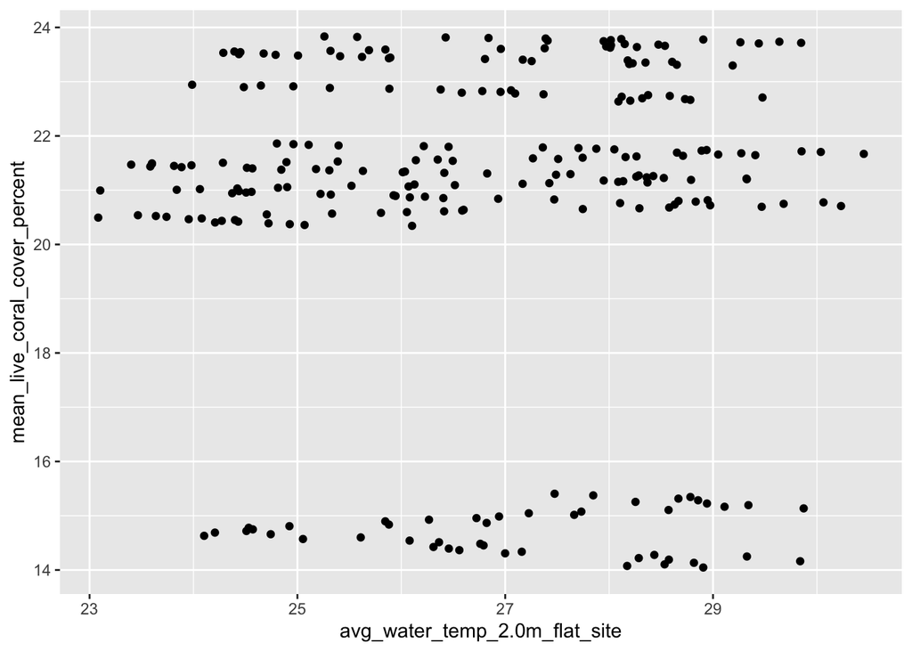

```r
read_csv("cleaned_data/temperature_and_coral_cover.csv") %>%
    ggplot(aes(avg_water_temp_2.0m_flat_site, mean_live_coral_cover_percent)) +
    geom_point()
```

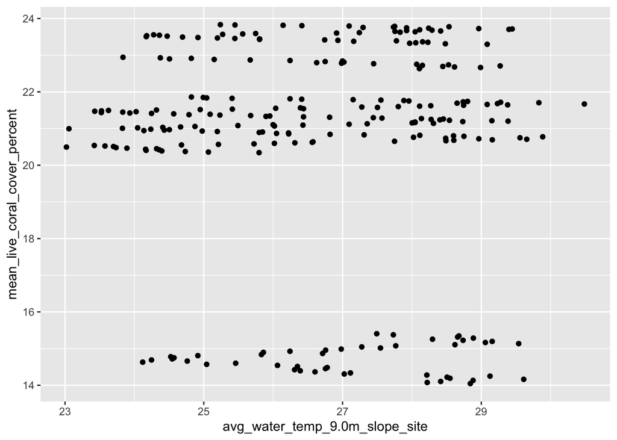

```r
read_csv("cleaned_data/temperature_and_coral_cover.csv") %>%
    ggplot(aes(avg_water_temp_9.0m_slope_site, mean_live_coral_cover_percent)) +
    geom_point()
```

So, we will examine a relationship between water temperature and the number of unique species observed in the Great Barrier Reef. First, we can do some basic visualization by plotting the relationship between water temperatures at 2m and 9m with number of unique fish species observed.

```r
fish_temp <- read_csv("cleaned_data/fish_temp_data.csv")
```

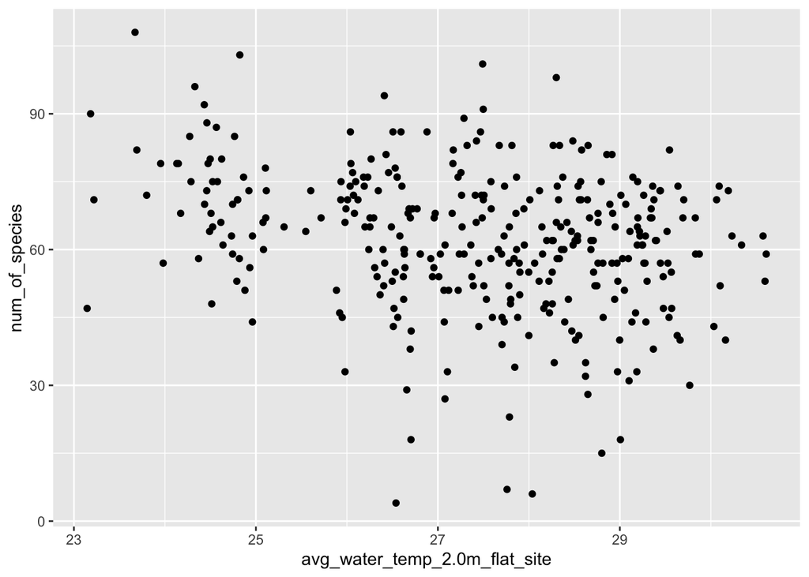

```r
# water temp at 2.0m
fish_temp %>% ggplot(aes(avg_water_temp_2.0m_flat_site, num_of_species)) + geom_point()
```

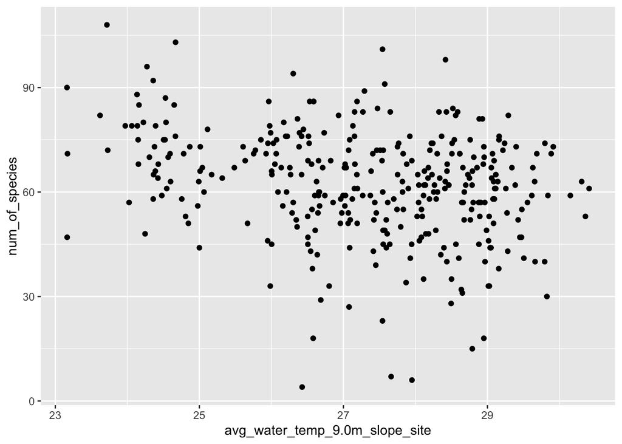

```r
# water temp at92.0m
fish_temp %>% ggplot(aes(avg_water_temp_9.0m_slope_site, num_of_species)) + geom_point()
```

### 1.2 Linear regression

```r
train_index <- createDataPartition(y=fish_temp$num_of_species, times=1, p = 0.6, list=FALSE)

train_set <- fish_temp[train_index, ]
test_set <- fish_temp[-train_index, ]
```

First, we will fit two models using each temperature at different depths as a single covariate, and then we will use both predictors to create a multiple linear regression model using both water temperatures as our covariates.

```r
fish_temp_2.0m <- lm(num_of_species ~ avg_water_temp_2.0m_flat_site, data=train_set)
summary(fish_temp_2.0m)
```

```
##
## Call:
## lm(formula = num_of_species ~ avg_water_temp_2.0m_flat_site,
##     data = train_set)
##
## Residuals:
##     Min      1Q  Median      3Q     Max
## -60.642  -9.383   1.483  10.835  39.348
##
## Coefficients:
##                               Estimate Std. Error t value Pr(>|t|)
## (Intercept)                   147.9696    18.9875   7.793 3.33e-13 ***
## avg_water_temp_2.0m_flat_site  -3.1398     0.6904  -4.548 9.31e-06 ***
## ---
## Signif. codes:  0 '***' 0.001 '**' 0.01 '*' 0.05 '.' 0.1 ' ' 1
##
## Residual standard error: 15.78 on 203 degrees of freedom
## Multiple R-squared:  0.09247,    Adjusted R-squared:  0.088
## F-statistic: 20.68 on 1 and 203 DF,  p-value: 9.308e-06
```

```r
fish_temp_9.0m <- lm(num_of_species ~ avg_water_temp_9.0m_slope_site, data=train_set)
summary(fish_temp_9.0m)
```

```
##
## Call:
## lm(formula = num_of_species ~ avg_water_temp_9.0m_slope_site,
##     data = train_set)
##
## Residuals:
##     Min      1Q  Median      3Q     Max
## -60.695  -9.553   1.762  10.766  39.868
##
## Coefficients:
##                                Estimate Std. Error t value Pr(>|t|)
## (Intercept)                    149.0373    19.2860   7.728 4.96e-13 ***
## avg_water_temp_9.0m_slope_site  -3.1915     0.7041  -4.533 9.94e-06 ***
## ---
## Signif. codes:  0 '***' 0.001 '**' 0.01 '*' 0.05 '.' 0.1 ' ' 1
##
## Residual standard error: 15.78 on 203 degrees of freedom
## Multiple R-squared:  0.09191,    Adjusted R-squared:  0.08744
## F-statistic: 20.55 on 1 and 203 DF,  p-value: 9.935e-06
```

Using both temperatures as our covariates

```r
fish_temp <- lm(num_of_species ~ avg_water_temp_2.0m_flat_site + avg_water_temp_9.0m_slope_site, data=train_set)
summary(fish_temp)
```

```
##
## Call:
## lm(formula = num_of_species ~ avg_water_temp_2.0m_flat_site +
##     avg_water_temp_9.0m_slope_site, data = train_set)
##
## Residuals:
##     Min      1Q  Median      3Q     Max
## -60.664  -9.433   1.532  10.496  39.489
##
## Coefficients:
##                                Estimate Std. Error t value Pr(>|t|)
## (Intercept)                    148.4788    19.3829   7.660 7.57e-13 ***
## avg_water_temp_2.0m_flat_site   -2.3014     6.0711  -0.379    0.705
## avg_water_temp_9.0m_slope_site  -0.8604     6.1899  -0.139    0.890
## ---
## Signif. codes:  0 '***' 0.001 '**' 0.01 '*' 0.05 '.' 0.1 ' ' 1
##
## Residual standard error: 15.81 on 202 degrees of freedom
## Multiple R-squared:  0.09256,    Adjusted R-squared:  0.08357
## F-statistic:  10.3 on 2 and 202 DF,  p-value: 5.493e-05
```

```r
pred_2.0m <- predict(fish_temp_2.0m, test_set)
pred_9.0m <- predict(fish_temp_9.0m, test_set)

postResample(pred = pred_2.0m, obs = test_set$num_of_species)
```

```
##       RMSE   Rsquared        MAE
## 14.2806686  0.0522644 11.2966291
```

```r
postResample(pred = pred_9.0m, obs = test_set$num_of_species)
```

```
##        RMSE    Rsquared         MAE
## 14.18930637  0.05894285 11.15867310
```

We can assess this visually to confirm our results.

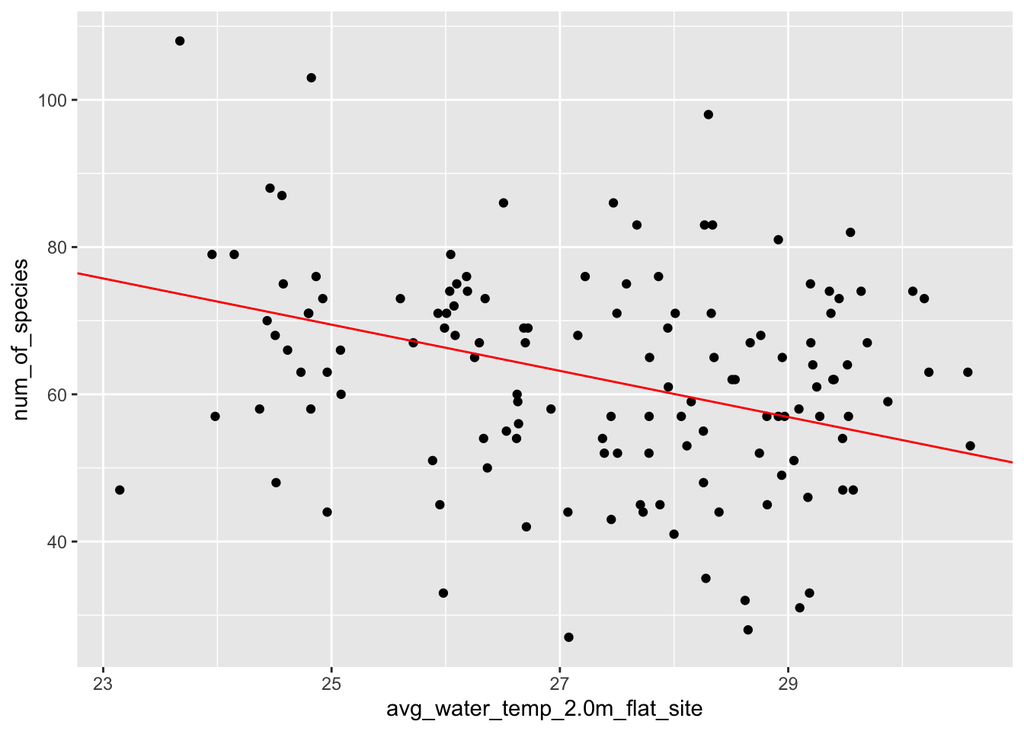

```r
# water temp at 2.0m
test_set %>%
    ggplot(aes(avg_water_temp_2.0m_flat_site, num_of_species)) +
    geom_point() +
    geom_abline(intercept=fish_temp_2.0m$coefficients[1], slope=fish_temp_2.0m$coefficients[2], col="red")
```

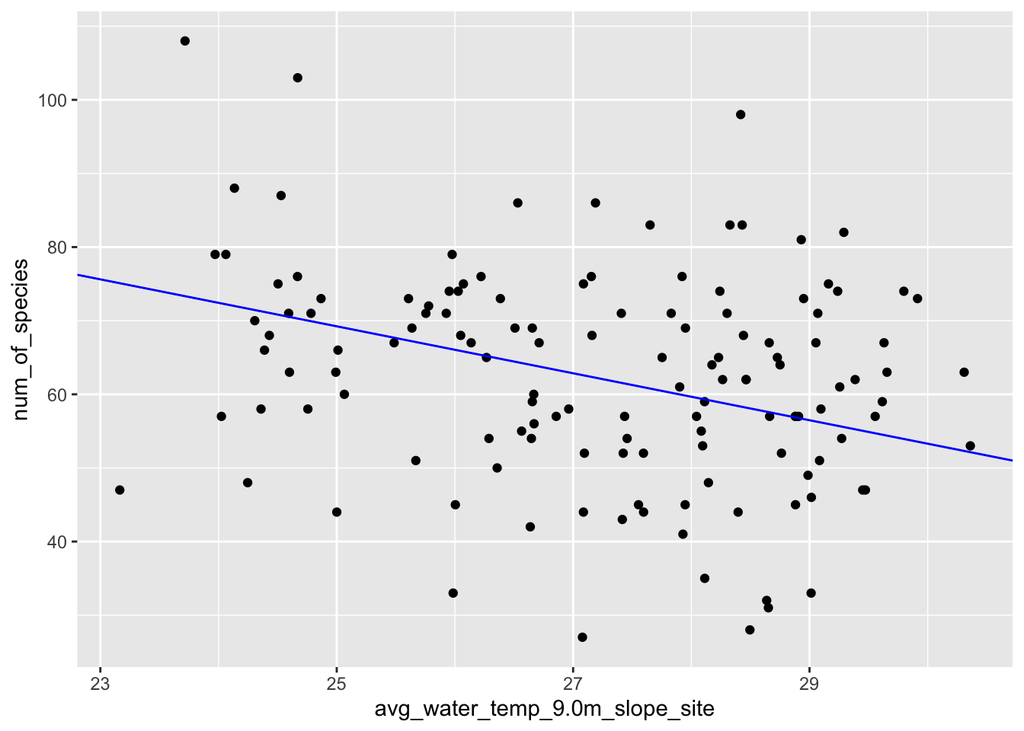

```r
# water temp at 9.0m
test_set %>%
    ggplot(aes(avg_water_temp_9.0m_slope_site, num_of_species)) +
    geom_point() +
    geom_abline(intercept=fish_temp_9.0m$coefficients[1], slope=fish_temp_9.0m$coefficients[2], col="blue")
```

They both perform very similarly, and choosing either water temperature as our predictor will yield similar results.

## 2. Binary classification on predicting presence of Halophila Ovalis in the Great Barrier Reef from 1999 - 2003.

## 2.1 Data exploratory analysis and visualization

```r
h_ovalis_data <- read_csv("cleaned_data/h_ovalis_monthly_presence.csv")
head(h_ovalis_data)
```

| month | year | H_OVALIS | SEDIMENT | TIDAL | DEPTH | monthly_avg_temp_2.0m | monthly_avg_temp_9.0m | monthly_mean_coral_cover_percentage | monthly_fish_species |
| --- | --- | --- | --- | --- | --- | --- | --- | --- | --- |
| 1 | 1999 | Yes | Sand | subtidal | 10.90880 | 29.19104 | 29.04768 | 23.28456 | 54.5 |
| 1 | 1999 | No | Sand | subtidal | 3.91641 | 29.19104 | 29.04768 | 23.28456 | 54.5 |
| 1 | 1999 | Yes | Mud | subtidal | 4.59669 | 29.19104 | 29.04768 | 23.28456 | 54.5 |
| 1 | 1999 | No | Mud | intertidal | 0.00000 | 29.19104 | 29.04768 | 23.28456 | 54.5 |
| 1 | 1999 | No | Mud | subtidal | 8.04107 | 29.19104 | 29.04768 | 23.28456 | 54.5 |
| 1 | 1999 | No | Sand | subtidal | 3.80795 | 29.19104 | 29.04768 | 23.28456 | 54.5 |

```r
h_ovalis_data$H_OVALIS <- as.factor(ifelse(h_ovalis_data$H_OVALIS=="Yes", 1, 0))
h_ovalis_data$TIDAL <- as.factor(ifelse(h_ovalis_data$TIDAL=="intertidal", 1, 0))

h_ovalis_data$MUD <- ifelse(h_ovalis_data$SEDIMENT == "Mud", 1, 0)
h_ovalis_data$MUD <- as.factor(h_ovalis_data$MUD)

h_ovalis_data$SEDIMENT <- factor(h_ovalis_data$SEDIMENT,
                                 levels = c("Mud", "Sand", "Reef", "Rock", "Rubble", "Shell", "Gravel"),
                                 labels = c(0, 1, 2, 3, 4, 5, 6),
                                 ordered = FALSE)

head(h_ovalis_data)
```

| month | year | H_OVALIS | SEDIMENT | TIDAL | DEPTH | monthly_avg_temp_2.0m | monthly_avg_temp_9.0m | monthly_mean_coral_cover_percentage | monthly_fish_species | MUD |
| --- | --- | --- | --- | --- | --- | --- | --- | --- | --- | --- |
| 1 | 1999 | 1 | 1 | 0 | 10.90880 | 29.19104 | 29.04768 | 23.28456 | 54.5 | 0 |
| 1 | 1999 | 0 | 1 | 0 | 3.91641 | 29.19104 | 29.04768 | 23.28456 | 54.5 | 0 |
| 1 | 1999 | 1 | 0 | 0 | 4.59669 | 29.19104 | 29.04768 | 23.28456 | 54.5 | 1 |
| 1 | 1999 | 0 | 0 | 1 | 0.00000 | 29.19104 | 29.04768 | 23.28456 | 54.5 | 1 |
| 1 | 1999 | 0 | 0 | 0 | 8.04107 | 29.19104 | 29.04768 | 23.28456 | 54.5 | 1 |
| 1 | 1999 | 0 | 1 | 0 | 3.80795 | 29.19104 | 29.04768 | 23.28456 | 54.5 | 0 |

We suspect that there’s some relationship between halophila ovalis presence and the depth and sediment in which they were discovered. Let’s visualize our data to confirm.

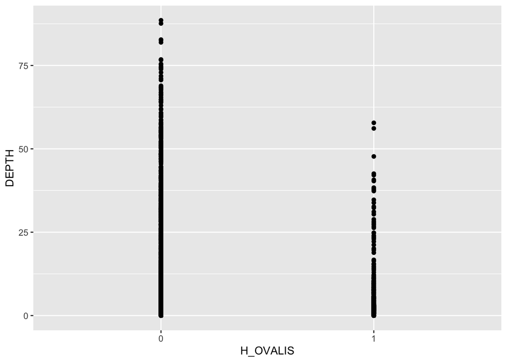

```r
h_ovalis_data %>%
    ggplot(aes(H_OVALIS, DEPTH)) + geom_point(pch = 21, fill="black")
```

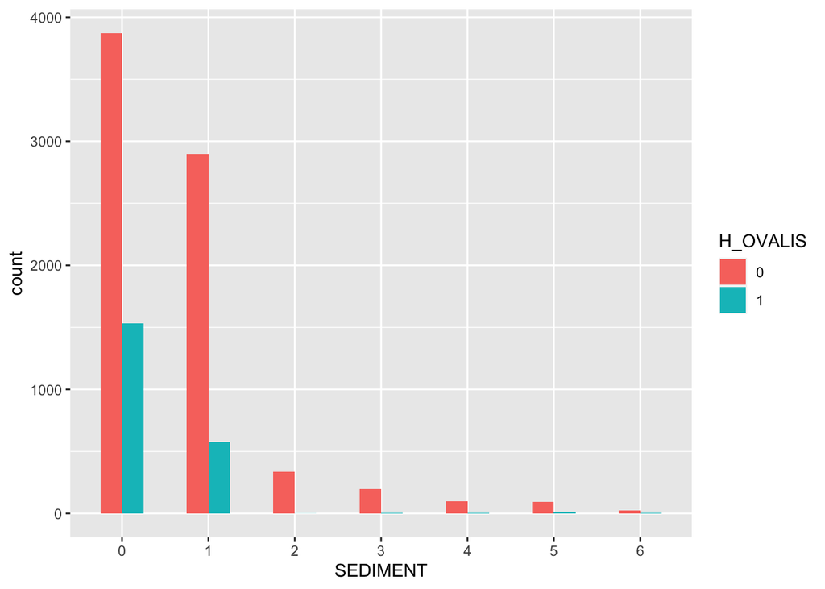

```r
h_ovalis_data %>%
    ggplot(aes(SEDIMENT, fill=H_OVALIS)) + geom_bar(width=.5, position = "dodge")
```

We will build a model predicting the presence of halophila ovalis using depth and sediment as predictors. We can use multiple types of classification methods including logistic regression, naive Bayes, QDA and random forest, but for the project, we will limit ourselves to logistic regression, and random forest to compare and contrast the results between the two models.

## 2.2 Logistic regression

First, we partition our data set into train and test sets. Since we have a lot more data here than in the linear regression model, we will partition it by 75%-25%.

```r
h_ovalis_subset <- h_ovalis_data %>% dplyr::select(H_OVALIS, DEPTH, SEDIMENT, MUD)
hovalis_train_ind <- createDataPartition(y = h_ovalis_subset$H_OVALIS, p=0.75, list=FALSE)

train_set <- h_ovalis_subset[hovalis_train_ind, ]
test_set <- h_ovalis_subset[-hovalis_train_ind, ]
```

The logistic regression model is as follows:

```r
glm_fit <- glm(H_OVALIS ~ DEPTH + SEDIMENT,
               data=train_set,
               family="binomial")

summary(glm_fit)
```

```
##
## Call:
## glm(formula = H_OVALIS ~ DEPTH + SEDIMENT, family = "binomial",
##     data = train_set)
##
## Deviance Residuals:
##      Min        1Q    Median        3Q       Max
## -0.84930  -0.82092  -0.64216  -0.00038   2.68393
##
## Coefficients:
##               Estimate Std. Error z value Pr(>|z|)
## (Intercept)  -0.834089   0.036991 -22.548  < 2e-16 ***
## DEPTH        -0.036492   0.005121  -7.126 1.03e-12 ***
## SEDIMENT1    -0.566093   0.063711  -8.885  < 2e-16 ***
## SEDIMENT2   -15.571435 151.412131  -0.103 0.918089
## SEDIMENT3    -2.739987   0.507815  -5.396 6.83e-08 ***
## SEDIMENT4    -1.709167   0.463594  -3.687 0.000227 ***
## SEDIMENT5    -1.196667   0.472171  -2.534 0.011264 *
## SEDIMENT6    -1.884398   1.029225  -1.831 0.067117 .
## ---
## Signif. codes:  0 '***' 0.001 '**' 0.01 '*' 0.05 '.' 0.1 ' ' 1
##
## (Dispersion parameter for binomial family taken to be 1)
##
##     Null deviance: 7654.9  on 7238  degrees of freedom
## Residual deviance: 7250.9  on 7231  degrees of freedom
## AIC: 7266.9
##
## Number of Fisher Scoring iterations: 15
```

Fit model to test data:

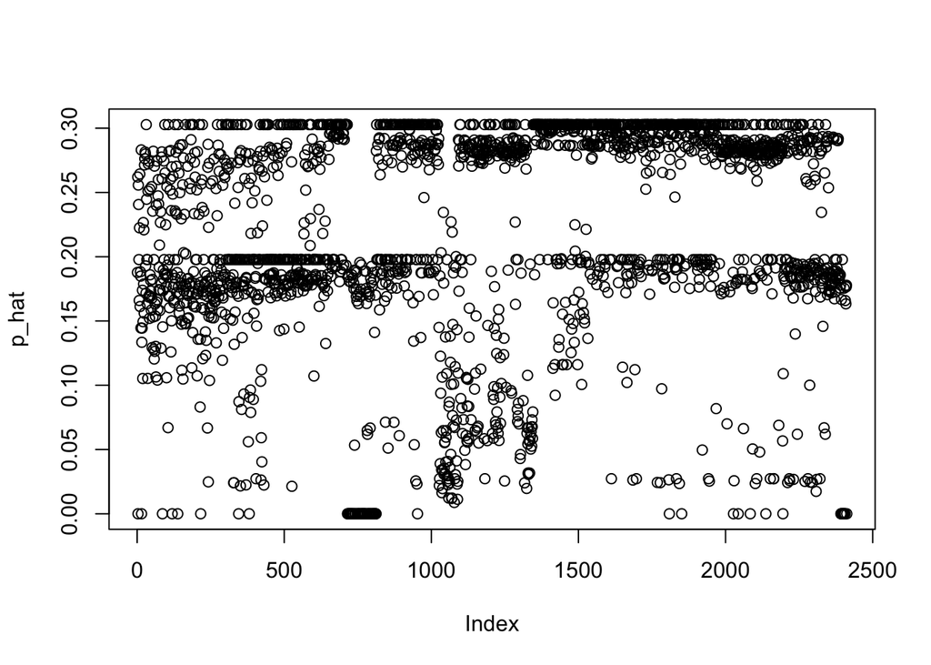

```r
p_hat <- predict(glm_fit, newdata = test_set, type = "response")

plot(p_hat)
```

```r
#p_hat <- predict(glm_fit, newdata = test_set, type = "response"
y_hat <- ifelse(p_hat > 0.2, 1, 0)

confusionMatrix(data = as.factor(y_hat), reference = test_set$H_OVALIS )
```

```
## Confusion Matrix and Statistics
##
##           Reference
## Prediction   0   1
##          0 976 149
##          1 902 385
##
##                Accuracy : 0.5643
##                  95% CI : (0.5442, 0.5842)
##     No Information Rate : 0.7786
##     P-Value [Acc > NIR] : 1
##
##                   Kappa : 0.16
##
##  Mcnemar's Test P-Value : <2e-16
##
##             Sensitivity : 0.5197
##             Specificity : 0.7210
##          Pos Pred Value : 0.8676
##          Neg Pred Value : 0.2991
##              Prevalence : 0.7786
##          Detection Rate : 0.4046
##    Detection Prevalence : 0.4664
##       Balanced Accuracy : 0.6203
##
##        'Positive' Class : 0
##
```

We see that our model is only accurate for about half of the predictions, which is not good. Specifically, it does not have good sensitivity. So, let’s try a random forest to see if that performs better.

## 2.3 Random forest

```r
library(randomForest)
rf_fit <- randomForest(H_OVALIS ~ DEPTH + SEDIMENT,
                       data=train_set,
                       mtry = 2)
rf_fit
```

```
##
## Call:
##  randomForest(formula = H_OVALIS ~ DEPTH + SEDIMENT, data = train_set,      mtry = 2)
##                Type of random forest: classification
##                      Number of trees: 500
## No. of variables tried at each split: 2
##
##         OOB estimate of  error rate: 26.19%
## Confusion matrix:
##      0   1 class.error
## 0 4916 720   0.1277502
## 1 1176 427   0.7336245
```

```r
rf_pred <- predict(rf_fit, newdata = test_set, type = "response")
confusionMatrix(table(pred = rf_pred, reference = test_set$H_OVALIS))
```

```
## Confusion Matrix and Statistics
##
##     reference
## pred    0    1
##    0 1638  370
##    1  240  164
##
##                Accuracy : 0.7471
##                  95% CI : (0.7292, 0.7643)
##     No Information Rate : 0.7786
##     P-Value [Acc > NIR] : 0.9999
##
##                   Kappa : 0.1964
##
##  Mcnemar's Test P-Value : 1.76e-07
##
##             Sensitivity : 0.8722
##             Specificity : 0.3071
##          Pos Pred Value : 0.8157
##          Neg Pred Value : 0.4059
##              Prevalence : 0.7786
##          Detection Rate : 0.6791
##    Detection Prevalence : 0.8325
##       Balanced Accuracy : 0.5897
##
##        'Positive' Class : 0
##
```

```r
get_accuracy <- function(fit, model_type) {
    pred <- predict(fit, newdata = test_set, type = "response")

    if (model_type == "rf") {
        confusionMatrix(table(pred = pred, reference = test_set$H_OVALIS))$overall[1]
    }
    else if (model_type == "logistic") {
        y_hat <- ifelse(pred > 0.175, 1, 0)
        confusionMatrix(data = as.factor(y_hat), reference = as.factor(test_set$H_OVALIS) )$overall[1]
    }
}

get_accuracy(glm_fit, "logistic")
```

```
##  Accuracy
## 0.3946932
```

```r
get_accuracy(rf_fit, "rf")
```

```
##  Accuracy
## 0.7470978
```

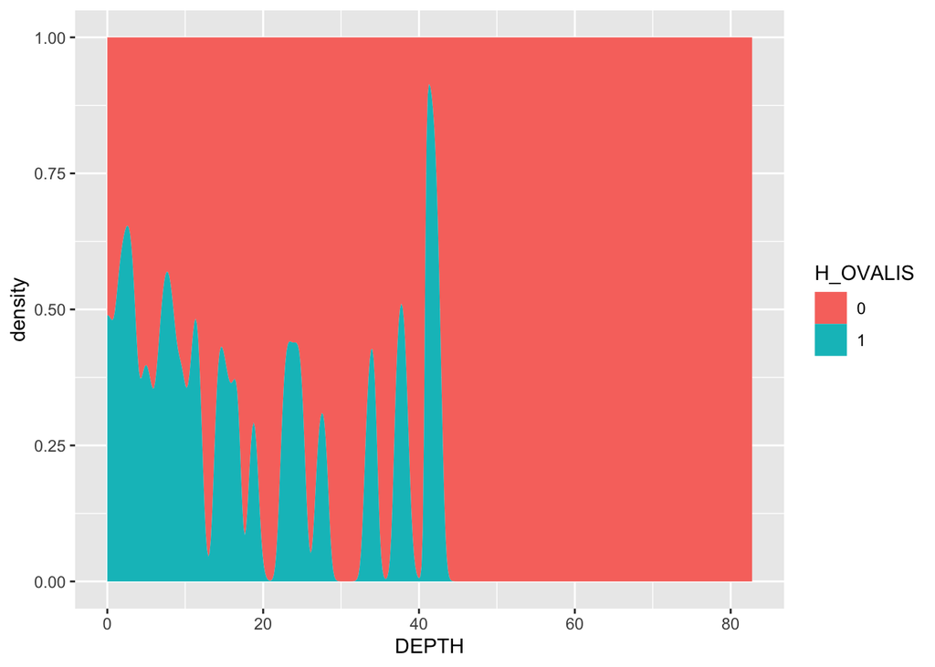

```r
ggplot(test_set, aes(x=DEPTH, fill = H_OVALIS)) +
  geom_density(position = position_fill(), size = 0)
```

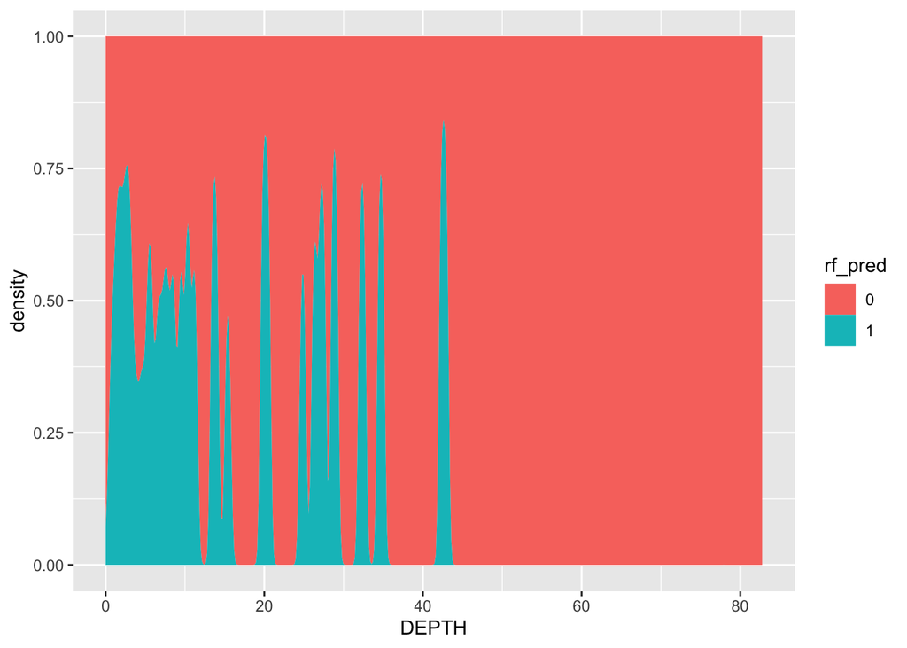

```r
ggplot(test_set, aes(x=DEPTH,  fill = rf_pred)) +
  geom_density(position = position_fill(), size = 0)
```

```r
variable_importance <- importance(rf_fit)

tmp <- tibble(feature = rownames(variable_importance),
                  Gini = variable_importance[,1]) %>%
                  arrange(desc(Gini))

tmp
```

| feature | Gini |
| --- | --- |
| DEPTH | 1677.74028 |
| SEDIMENT | 99.00799 |

We see that DEPTH was a much better predictor of the presence of halophila ovalis than the sediment type in which they were discovered.